Four scenarios + GrBP · Joint PDF derivationsJOINT PDF FACTORIZATION

# Joint PDF factorization

From a generative model to local factors.

Point and extended objects.  
Known and unknown object counts.

**GrBP:** Precluster, then associate whole groups.

**S1**Point · known

**S2**Point · unknown

**S3**Extended · known

**S4**Extended · unknown

Follow the four raw-measurement scenarios, then GrBP. The original S1–S4 slides are preserved. GrBP derives the approximate joint PDF after a fixed external partition.

The four scenarios and a GrBP derivationJOINT PDF FACTORIZATION

# Two modeling choices shape the graph.

**Object model:** one measurement or several per scan.

**Object count:** fixed, or represented by potential objects and existence variables.

|  | Known count | Unknown count |
| --- | --- | --- |
| Point | S1 · exclusivity | S2 · existence + new objects |
| Extended | S3 · Poisson counts | S4 · anchored new objects |

**GrBP · Preclustering → group association**  
Fixed groups and an unknown target count

Each matrix entry jumps to the first slide of that scenario. The article uses n_t point targets, K known extended objects, and underlined K legacy potential objects in Scenario 4. GrBP follows S4 and replaces raw-point assignments with whole-group assignments after a fixed preclustering step.

Common techniqueJOINT PDF FACTORIZATION

# Prior × allocation × measurements

1. Read the counts from the association.
2. Insert the Poisson count laws.
3. Cancel allocation factorials.
4. Collect constants; marginalize auxiliaries.

collects object states; collects associations and any existence variables needed for the allocation.

Measurements are an ordered vector with observed length m. Retain m in the count/allocation kernel before conditioning on the observed data. The Poisson allocation expression is a joint count-and-association probability, not a normalized distribution of associations at a fixed count. This convention makes the restored article’s final factorizations precise.

Notation and model boundaryJOINT PDF FACTORIZATION

# What is observed, and what is inferred?

**Observed:** the ordered measurement vector and its count.

**Inferred:** states, associations, and existence when applicable.

Clutter parameters and measurement models are supplied.

For fixed data and clutter model, is constant in the inferred states and assignments.

Use the restored article’s notation throughout: P_d for point detection, mu_m for the state-dependent EO measurement rate, and mu_c f_c for clutter intensity (mu_fa f_fa in S4). Final products are displayed as posteriors conditioned on Z, including its observed count. The independent predicted-prior assumption is essential.

S1 · Point / known countJOINT PDF FACTORIZATION

# Each target makes at most one claim.

existing point targets; measurements.

A nonzero claim must be unique. Several targets may have the null claim.

A valid example is a=(1,3,0): two detections and one miss. The assignment (1,1,0) is invalid because two targets claim measurement 1. Clutter is the complement of the claimed measurements.

S1 · LikelihoodJOINT PDF FACTORIZATION

# Divide by the clutter explanation.

Claimed measurements use the target likelihood.

Unclaimed measurements use .

Multiplying and dividing by clutter densities leaves a ratio for each detection.

This algebra assumes a positive clutter density on the measurement support. The product over all observed clutter densities is independent of object states and assignments and can be absorbed into the posterior normalizer.

S1 · Count cancellationJOINT PDF FACTORIZATION

# A permutation removes the clutter factorial.

Given the detected targets, all consistent assignments to distinct measurement slots are uniform.

The clutter Poisson factorial cancels the allocation factorial.

One factor remains for each detected target.

The association/count kernel also contains psi(a), a P_d factor per detection, and a (1-P_d) factor per missed target. Its sum over a is the measurement-count probability, not necessarily one.

S1 · Local factorsJOINT PDF FACTORIZATION

# Detection ratios and missed detections

Each target contributes its prior and one local factor .

The consistency factor couples their association choices.

This is the Scenario 1 result of the restored page, with the fixed measurement vector moved to the conditioning side. Unknown object states are not replaced by point estimates.

S1 · Factor graphJOINT PDF FACTORIZATION

# One chain per target; one shared constraint.

Prior → state → local likelihood → association.

forbids duplicate nonzero claims.

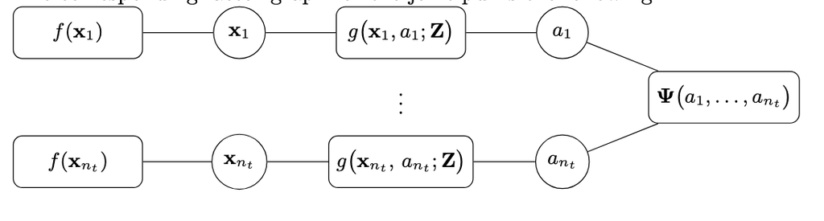

Original Scenario 1 factor graph from the restored article.

Read each horizontal chain left to right. The single global consistency factor touches every a_i. This diagram displays a factorization; deriving or running the message updates is a subsequent inference step.

S2 · Point / unknown countJOINT PDF FACTORIZATION

# Augment each state with existence.

Legacy potential objects carry .

An existing object can be detected or missed. A nonexistent object cannot claim a measurement.

The legacy prior f(underlined y_i) carries existence mass. Its nonexistent branch uses a normalized dummy density. A null association alone does not tell us whether the object exists.

S2 · Count cancellationJOINT PDF FACTORIZATION

# Split unclaimed points into new objects and clutter.

Each measurement has a new potential object .

On the valid support, new-object and clutter counts follow directly from existence and association.

Multiply the inverse binomial split and inverse permutation by the Poisson PMFs for clutter and newly detected objects. Both factorials cancel. In this measurement-anchored convention, mu_n f_n describes newly detected objects; using an intensity of all physical births instead would require the corresponding detection model.

S2 · New-object factorJOINT PDF FACTORIZATION

# A claimed point cannot also start a new object.

contains points already claimed by legacy objects.

A valid new-object branch needs both the birth intensity and state density .

The bar r=0 branch is the dummy density regardless of whether a legacy object claimed this point. If the point is unclaimed and bar r=0, it is clutter. A new object with bar r=1 must use an unclaimed point.

S2 · Factorized posteriorJOINT PDF FACTORIZATION

# Legacy chains plus new-object factors

The same enforces unique legacy claims.

Each new-object factor depends on the entire legacy association vector.

This is the restored Scenario 2 final factorization. There is one new potential object per measurement, not an assertion that every measurement creates a confirmed track.

S2 · Factor graphJOINT PDF FACTORIZATION

# New candidates share the association decisions.

Legacy chains remain on the left.

New candidates add factors.

The colored edges prevent a legacy claim and a new-object claim from explaining the same point.

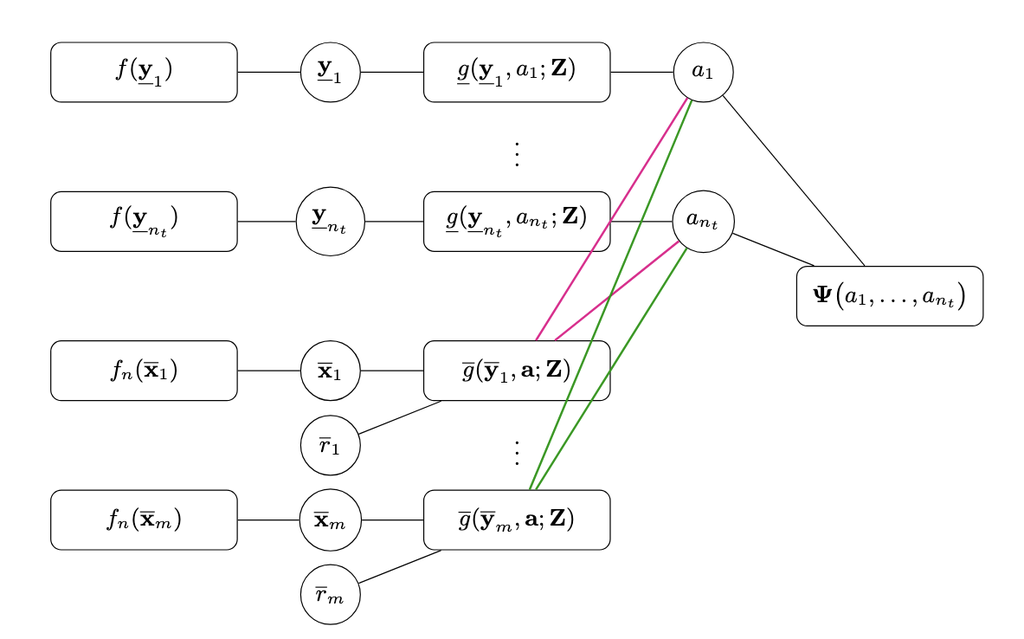

Original Scenario 2 graph.

The bar g factors are functions of the association vector. Existence variables stay part of the object state; measurements are observed parameters of the likelihood factors.

S3 · Extended / known countJOINT PDF FACTORIZATION

# Let every measurement name its source.

The extended state is .

Several measurements can share one object. Each measurement has exactly one source; means clutter.

T^k is the measurement cell induced by an association hypothesis. It is not a grouping supplied in advance. The count is conditionally Poisson at each object state, including the possibility of zero. No global point-target exclusivity factor is needed.

S3 · Count cancellationJOINT PDF FACTORIZATION

# The allocation binomials telescope.

Each object selects its cell from the remaining measurements.

The allocation contributes a factorial for each cell, cancelling the Poisson factorials.

The total count includes object-generated measurements and clutter. Keep all state-dependent exponentials. The only count prefactor removed after conditioning on data is the clutter baseline C(Z,m).

S3 · Local factorsJOINT PDF FACTORIZATION

# One unary factor, then one edge per point

The zero-count exponential belongs to the object’s unary factor.

An assigned point contributes a measurement-rate likelihood ratio. Every other edge is neutral.

The exponential exp(-mu_m(y_k)) appears once per object, including when its cell is empty. The pure Poisson model already permits zero detections. A separate object-level P_D gate requires a different empty-cell term and a consistent nonempty branch.

S3 · Factorized posteriorJOINT PDF FACTORIZATION

# Put all edges inside the object product.

Each object contributes its unary and all pairwise factors.

All objects meet at the measurement-oriented association variables.

This is the bracketed Scenario 3 result in the restored source. A hypothesis b_i=k activates the kth object’s ratio for measurement i; the other objects’ factors for that measurement are one.

S3 · Factor graphJOINT PDF FACTORIZATION

# Many measurements may connect to the same object.

Each object–measurement pair has a factor .

Variable selects the source of measurement .

The source choice itself gives each measurement one owner.

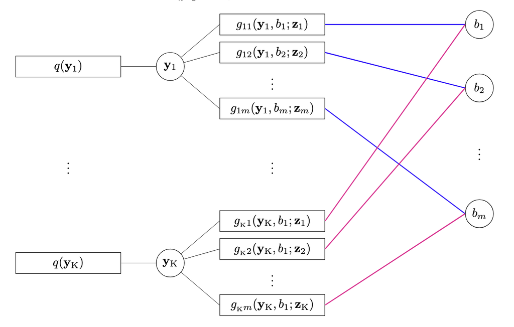

Original Scenario 3 graph.

The graph has one object-state variable per known extended object and one association variable per measurement. The unary incorporates both the independent prior and the object-level Poisson exponential.

S4 · Extended / unknown countJOINT PDF FACTORIZATION

# Anchor each new object to its first point.

legacy potential objects and new potential objects.

New candidate is anchored at measurement and can explain later measurements.

First means smallest index in the chosen ordered measurement vector, not physical time. New candidate k exists exactly when b_k=underlined K+k. For K=0, (1,1,1) is valid; (0,1,1) violates the anchor condition even though every entry obeys the domain bound.

S4 · Measurement countsJOINT PDF FACTORIZATION

# A newly detected object has a nonzero count.

Newly detected objects use a zero-truncated Poisson count.

Existing legacy objects use an ordinary Poisson count; nonexistent ones generate zero points.

Here mu_n f_n is the intensity of newly detected objects. The truncated expression is defined at a positive measurement rate. Keep its state-dependent denominator under this birth convention.

S4 · Auxiliary constructionJOINT PDF FACTORIZATION

# Expand first, then remove the auxiliaries.

1. Introduce newly detected states and their associations.
2. Map them onto measurement-anchored candidates.
3. Integrate copied states; sum auxiliary labels and mappings.

This follows the restored page’s three-step auxiliary construction. State-copy delta functions transfer tilde states to the corresponding bar states. The deterministic mapping indicator remains inside the joint kernel; do not treat a mapping-restricted kernel as a normalized conditional without its normalizer.

S4 · MarginalizationJOINT PDF FACTORIZATION

# Relabeling cancels the new-object factorial.

Permuting the auxiliary labels of newly detected objects gives the same canonical assignment.

The sum contributes .

The displayed product of l_k factorials runs over all legacy and newly detected objects. The state densities, measurement-rate powers, exponentials and zero-truncation denominators remain in the state-dependent factors; only the combinatorial cancellation is shown here.

S4 · Conditional-prior resultJOINT PDF FACTORIZATION

# The count model is complete; values come next.

: existing new candidates. : existing legacy objects.

This is the restored page’s conditional prior f(bar y,b,M | underlined y). It retains the count M. The spatial measurement values Z have not entered yet. The indicator 1{l=0} is the same discrete delta used in the article.

S4 · Unary potentialsJOINT PDF FACTORIZATION

# Separate legacy prediction and new-object evidence.

includes the legacy existence mass and its conditional state density.

The new-object unary carries the detected-object intensity and the truncated-count normalization.

These are the restored source’s single-scan unaries. For a nonexistent legacy object retain f^-(underlined y), not the scalar one. The paper’s multi-scan pseudo-transition is a different object from this already-predicted single-scan unary.

S4 · Legacy measurement edgesJOINT PDF FACTORIZATION

# An absent object cannot own a point.

Write the rate-weighted likelihood ratio as .

Assignment to an existing object activates that ratio; an absent object forbids the assignment.

Rho is only a display abbreviation, not a new model parameter. For a legacy edge evaluate it at the underlined state; for a new edge evaluate it at the bar state. The denominator is the source’s false-alarm intensity mu_fa f_fa.

S4 · New-object anchorJOINT PDF FACTORIZATION

# The anchor enforces existence in both directions.

If candidate exists, measurement must belong to it.

If it does not exist, the anchor cannot name it.

Here rho_kk is evaluated at bar y_k for measurement k. The zero branch for an existing candidate whose anchor is assigned elsewhere is essential. A domain bound alone does not enforce this rule.

S4 · Later measurementsJOINT PDF FACTORIZATION

# An extended new object needs more than its anchor.

For every , candidate can explain measurement through .

Earlier measurements cannot refer to a later candidate.

Rho_ki is evaluated at bar y_k for measurement i. This factor is neutral if the existing candidate does not own i. If the candidate does not exist, all claims to it are excluded. The original source explicitly includes these later-measurement factors.

S4 · Final factorizationJOINT PDF FACTORIZATION

# Two families of local products

Legacy objects connect to every measurement. New candidates connect to their anchor and all later measurements.

This is the complete single-scan posterior factorization in the restored article. Each new candidate contributes bar q, one special anchor bar g, and ordinary later factors bar h. Source variables enforce one source per point while permitting multiple points per object.

S4 · Factor graphJOINT PDF FACTORIZATION

# Prediction, birth, and measurement edges

: legacy prediction.

: new-object unary.

The anchor and later edges encode the canonical labeling.

Red annotations identify BP messages on this graph.

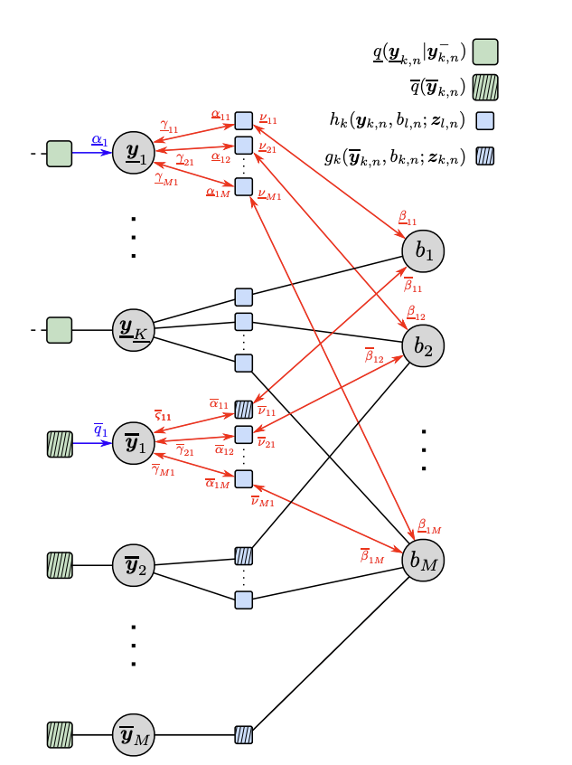

Original Scenario 4 graph. Its h / ḡ labels follow the source figure.

The graph reproduced from the restored article includes message annotations. In this deck underline g names legacy pairwise factors and bar h names later-new-object factors, matching the article’s final equations. The source figure uses the paper’s h/g-bar labels. No new explicit BP iteration scheme is introduced here.

Derivation for GrBP / Fixed partitionJOINT PDF FACTORIZATION

# Derivation for GrBP

GrBP uses grouped measurements: external clustering fixes one partition.

Data association then decides which target explains each **whole group**.

Introduce one newborn candidate per group.

01 · OBSERVERaw detections

**↓**

02 · PRECLUSTERFixed partition

**↓**

03 · ASSOCIATEGroups → target choices

This is the requested alternative after S4. S4 infers individual measurement assignments; the GrBP derivation conditions on an externally supplied partition. This is an approximate conditional model. It does not model the probability that clustering produced the partition.

Derivation for GrBP / A.1JOINT PDF FACTORIZATION

# Points, groups, and targets are different counts.

raw detections form disjoint groups.

legacy components carry predicted beliefs.

Every component has kinematics, extent, and existence; is shorthand.

Eq. (A.1). The legacy prior factors under independent predicted component beliefs. There are n^t+n^g potential components, not necessarily that many actual targets. A single partition may contain many groups.

Derivation for GrBP / A · AssociationJOINT PDF FACTORIZATION

# Two variables record the same claim.

: legacy target claims group .

: group comes from legacy target .

leaves two alternatives: **newborn or clutter**.

Psi_pj is zero exactly when one of a^p=j and b^j=p holds and the other does not. Their product enforces one-to-one legacy-to-group claims. Newborn exclusion is additionally enforced by the newborn factor.

Derivation for GrBP / A · Count identitiesJOINT PDF FACTORIZATION

# Read the counts from the assignments.

Detected legacy targets, existing newborns, and clutter partition the groups on every feasible hypothesis.

D contains detected legacy indices; N contains group-indexed existing newborns. Legacy-claimed and newborn groups must be disjoint. On that support, n^c=n^g-n^d-n^n.

Derivation for GrBP / A.2JOINT PDF FACTORIZATION

# Separate the prior, allocation, and likelihood.

Condition throughout on the fixed partition . Its notation is suppressed in the equations.

Eq. (A.2), eq:joint_pdf_structured. This is the chain-rule decomposition on the valid association support. Subsequent group-count and conditional-independence approximations enter its factors. The clustering-output probability is not modeled.

Derivation for GrBP / A.3JOINT PDF FACTORIZATION

# Clutter groups have their own Poisson mean.

: mean number of clutter **groups**.

: mean number of **detected newborns**.

Generally : a clutter group can contain several detections.

Eq. (A.3), eq:pt_counts_distributions. The induced clutter-group count is approximated by a Poisson distribution. Preserve the approximation sign and do not replace mu_g with the raw clutter-detection mean.

Derivation for GrBP / A.3 → A.4JOINT PDF FACTORIZATION

# The allocation factorials cancel the count factorials.

Choose which unclaimed groups are newborns.

Assign detected legacy targets to distinct group slots.

Multiply by the two Poisson count laws; the remaining denominator is .

Paragraph after A.3. The inverse binomial is n^c! n^n!/(n^c+n^n)!. The inverse permutation is (n^c+n^n)!/n^g!, because n^g-n^d=n^c+n^n. Their product cancels both Poisson count factorials.

Derivation for GrBP / A.4JOINT PDF FACTORIZATION

# Keep the existence branches and newborn densities.

collects newborn state densities; is normalized. The nonempty legacy count mass enters the likelihood next.

Eq. (A.4), eq:I13. B is only an abbreviation for the product of f_n for existing newborns and f_d for absent candidates. A detected legacy branch contributes its existence indicator here; the e^-mu_m times product(mu_m f) term enters A.5. Read these terms together as the displayed joint kernel, not as a separately normalized association PMF. Do not insert another detection-probability multiplier.

Derivation for GrBP / A.5 · Group modelsJOINT PDF FACTORIZATION

# A detected newborn uses a nonempty-group likelihood.

A legacy group uses the extended-target Poisson likelihood.

A newborn is detected by definition, so condition on a nonzero count.

Keep one exponential per target, not one per point.

Paragraph following A.5. L_L and L_N are explicit display abbreviations for the group likelihoods. The zero-truncation denominator 1-exp(-mu_m(s)) belongs with the detected-newborn convention mu_n f_n. The group is nonempty and the truncated form uses positive detection probability.

Derivation for GrBP / A.5JOINT PDF FACTORIZATION

# Multiply the group likelihoods by source.

Conditioned on a feasible association, the approximate model treats groups as independent.

Eq. (A.5), eq:pt_group_like_count_split. Multiply the legacy likelihoods over D, newborn likelihoods over N, and clutter densities F_c over C. Conditional group independence is a model assumption after clustering.

Derivation for GrBP / A.5 → A.6JOINT PDF FACTORIZATION

# Divide each target group by its clutter explanation.

The product of all group clutter densities is a baseline for the entire scan.

Redistributing leaves **one** for every target-generated group.

Paragraph before A.6. F_c(Z^j) is the product of raw spatial clutter densities over that group. One clutter-group intensity is removed per target-generated group, not per detection. No additional group-size factorial is inserted.

Derivation for GrBP / A.6JOINT PDF FACTORIZATION

# Separate the constant and define the group ratio.

is fixed for the observed grouped scan and fixed model parameters.

abbreviates the per-point likelihood ratios inside group .

Eq. (A.6), eq:pt_constant_C. C may be dropped when normalizing the posterior over the stated unknowns. If comparing partitions or estimating clutter/birth parameters, it is no longer automatically constant. R_j is a presentation shorthand whose expansion reproduces A.7–A.8.

Derivation for GrBP / A.7JOINT PDF FACTORIZATION

# A legacy target has four local cases.

An existing target can claim a group or generate no detections.

A nonexistent target can only make a null claim.

The predicted prior remains a separate factor.

Eq. (A.7), eq:legacy_l_function, exactly after expanding R_a(s). The assigned/existing branch is exp(-mu_m) R_a/mu_g. The null/existing branch is exp(-mu_m); null/nonexistent is one; assigned/nonexistent is zero.

Derivation for GrBP / A.8JOINT PDF FACTORIZATION

# An unclaimed group can create one newborn.

: newborn and clutter compete.

: a legacy target already owns the group, so the newborn cannot exist.

The absent candidate carries dummy density .

Eq. (A.8), eq:new_l_function. Keep both mu_n f_n and the zero-truncation denominator. The absence branch f_d(s) applies whether or not the group is claimed by a legacy target. The candidate is indexed by the entire group.

Derivation for GrBP / A.9JOINT PDF FACTORIZATION

# The grouped joint PDF becomes a product of local factors.

Predicted priors × legacy factors × newborn factors × group-association consistency.

Eq. (A.9), eq:final_joint_pdf_local_factors. Preserve the approximation sign. Normalizing the displayed product for the fixed observed grouping defines the approximate-model posterior. BP then performs inference on this graph; loopy BP adds a separate inference approximation.

Derivation for GrBP / Model boundaryJOINT PDF FACTORIZATION

# Association cannot repair a fixed partition.

**S4:** infer assignments of individual detections; several points can choose the same target.

**GrBP:** infer whole-group assignments after external clustering.

One group per target.  
One source per group.

Target splits and cross-target merges are outside this model.

The number of groups is not the inferred number of targets.

The model conditions on one partition, excludes target splits and cross-target merges, and approximates the induced clutter-group count. It specifies neither a clustering algorithm nor its parameter calibration. Unknown target count is still represented by the legacy and newborn existence indicators.

Derivation for GrBP / Factor graphJOINT PDF FACTORIZATION

# Factor graph for GrBP

Legacy chains and group-indexed newborn chains meet at .

[figure not shown]

Circles: variables · Boxes: factors · Blue: prediction between scans. The central factor collects all pairwise association-consistency factors.

The graph uses n^t legacy components and n^g measurement groups, with the time index k shown. The central psi box abbreviates the product of Psi_pj(a^p,b^j), not a claim that the expanded BP graph is loop-free. The newborn density is already inside the newborn likelihood factor, so no extra newborn-prior factor is added. The observation-only constant C is omitted. The pale blue paths describe prediction across scans, separate from the black within-scan factor-graph edges.

SummaryJOINT PDF FACTORIZATION

# From raw measurements to fixed groups

**Unknown object count:** introduce potential objects and existence.

**Multiple points per object:** use measurement-oriented assignments and Poisson counts.

**GrBP:** precluster once, then associate whole groups.

| Case | Association | Coupling |
| --- | --- | --- |
| S1 | Target-oriented | Global exclusivity |
| S2 | Target-oriented | Exclusivity + new objects |
| S3 | Measurement-oriented | Object–point factors |
| S4 | Measurement-oriented | Legacy + anchor + later edges |
| GrBP | Group-level | Exclusive target–group factors |

S1–S4 retain raw-measurement assignments. GrBP conditions on one externally supplied partition and uses an approximate Poisson clutter-group model. The birth factors and count conventions must remain consistent within each model.

Before implementationJOINT PDF FACTORIZATION

# Check the tiny cases first.

1. Keep ordered-vector and finite-set conventions consistent.
2. Retain every state-dependent factor.
3. Verify counts and normalization by enumeration.
1. Keep in new-object factors.
2. Enforce the anchor condition and include every later edge.
3. Compare approximate BP marginals against exact inference on small scans.

These are the implementation checks at the end of the restored page. Count evidence, birth conventions, and association support should be checked before using the graph in a tracking implementation.

ReferencesJOINT PDF FACTORIZATION

# The page, the scans, and the primary papers

**R1 · Point-object models**  
Meyer et al., “Message passing algorithms for scalable multitarget tracking,” Proceedings of the IEEE, 2018.

**R2 · Extended-object model**  
Granström, Baum & Reuter, “Extended Object Tracking: Introduction, Overview and Applications.”

**R3 · Extended objects with uncertain count**  
Meyer & Williams, “Scalable Detection and Tracking of Geometric Extended Objects,” 2021.

The companion page contains the full derivations and original handwritten scans for S1–S4, plus the derivation for GrBP.

This presentation follows the restored Joint PDF factorization page. The original figures are embedded from its assets. Primary papers provide the published model context; handwritten scans are supplementary cross-checks.